# Final Project

Sreedevi Ravi

2/26/2021

ALY6000  
Final Project Report  
*Sreedevi Ravi*  
Prof. Dee Chiluiza, PhD  
Date:02/26/2021

**INTRODUCTION**

Data analytics is crucial for accurate decision-making and predictive analysis. The data is just a collection of numbers until we analyze and gather meaningful insights out of it. We need the right statistical measures at hand to design, visualize and communicate our findings.  
Reference:Bluman,A. G. (2017)

**General topic:**

The dataset provides the global sales figures for the company TargetCorp. The company deals with the sale of furniture, office supplies and technology for consumer, corporate and home-office segments. We have a global market spanning across Africa, Asia Pacific, Europe, LATAM and USCA. As the marketing analyst of the company, I need to identify the profits earned from each category we provide and the global market sales. There are sub-categories under each category which account for a difference in profits.

**Dataset description:**

The dataset contains 1000 observations of 24 variables. It consists of five numerical variables – Sales,Quantity,Discount,Profit and Shipping Cost. For uniquely identifying each entry there is RowID, OrderID, OrderDate, ShipDate, CustomerID. The Market we focus on are Africa, Asia Pacific, Europe, LATAM and USCA. There are three categories sold by the company – Furniture, Office Supplies and Technology . The categorical variables which are of interest currently are – Region, Market, Segment, Category and ShipMode.

**Plan**  
I plan to analyze the data in Excel first. This will help me in identifying the categorical variables which affected the profit and sales.  
After initial identification, statistical analysis will be performed on the numerical variables with R programming. The visualizations will be done in R for better understanding and presentation.

**ANALYSIS**  
**Task 1**

Observation:  
The dataset M6_project_dataset.csv was loaded into Datasets folder.The dataset was renamed as GobalSales while importing. While choosing datatypes,numeric was selected for continuous data and integer for discrete data.  
**Task 2**

```r
datatable(global_sales_matrix)
```

|  | Mean | Median | sd | Range |
| --- | --- | --- | --- | --- |
| Sales | 398.40649 | 350.835 | 293.948469704848 | 3406.28 |
| Quantity | 4.113 | 3 | 2.50449665671638 | 13 |
| Discount | 0.11004 | 0 | 0.172881017599522 | 0.8 |
| Profit | 49.54887 | 45.42 | 147.39459952044 | 1897.94 |
| Shipping Cost | 37.19112 | 40.625 | 18.7724052146533 | 393.48 |

**Task 3**

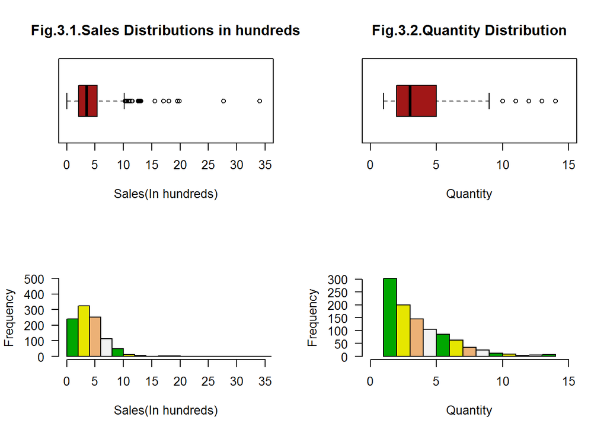

```r
par(mfcol=c(2,2))

boxplot(sales/100,
        horizontal = TRUE,
        las =1,
        col = c("#A11717", "#2E6DAC"),
        main = "Fig.3.1.Sales Distributions in hundreds",
        xlab = "Sales(In hundreds)",
        ylim = c(0,35))

hist(sales/100,
     col = terrain.colors(4),
     main = NA,
     xlab = "Sales(In hundreds)",
     ylim = c(0,500),
     xlim = c(0,35),
     breaks = 16,
     las = 1)

boxplot(qty,
        horizontal = TRUE,
        las =1,
        col = c("#A11717", "#2E6DAC"),
        main = "Fig.3.2.Quantity Distribution",
        xlab = "Quantity",
        ylim = c(0,15))

hist(qty,
     col = terrain.colors(4),
     main = NA,
     xlab = "Quantity",
     xlim = c(0,15),
     las = 1,
     breaks = 13)
```

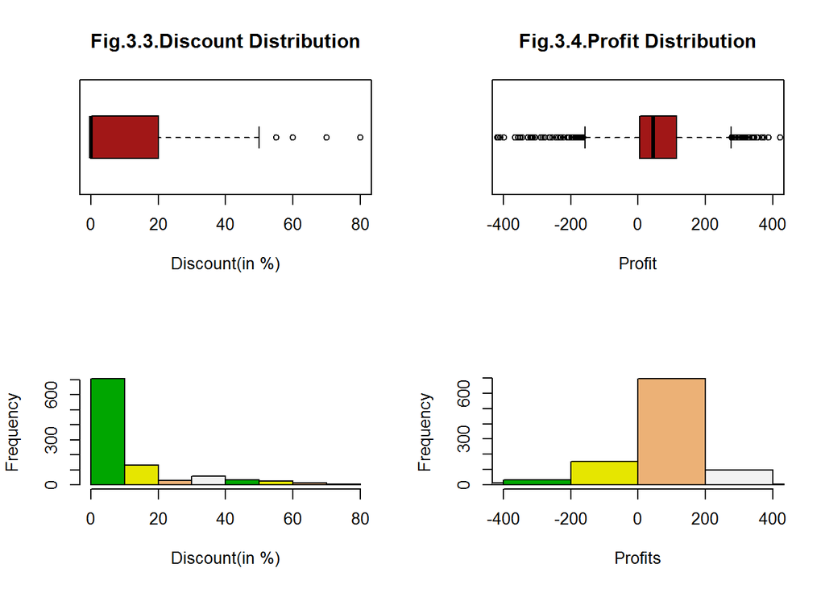

```r
par(mfcol=c(2,2))
boxplot(disc*100,
        horizontal = TRUE,
        las =1,
        col = c("#A11717", "#2E6DAC"),
        main = "Fig.3.3.Discount Distribution",
        xlab = "Discount(in %)",
        ylim = c(0,80) )

hist(disc*100,
     col = terrain.colors(4),
     main = NA,
     xlab = "Discount(in %)",
     xlim = c(0,80))

boxplot(profit,
        horizontal = TRUE,
        las =1,
        col = c("#A11717", "#2E6DAC"),
        main = "Fig.3.4.Profit Distribution",
        xlab = "Profit",
        ylim = c(-400,400))

hist(profit,
     col = terrain.colors(4),
     main = NA,
     xlab = "Profits",
     xlim = c(-400,400))
```

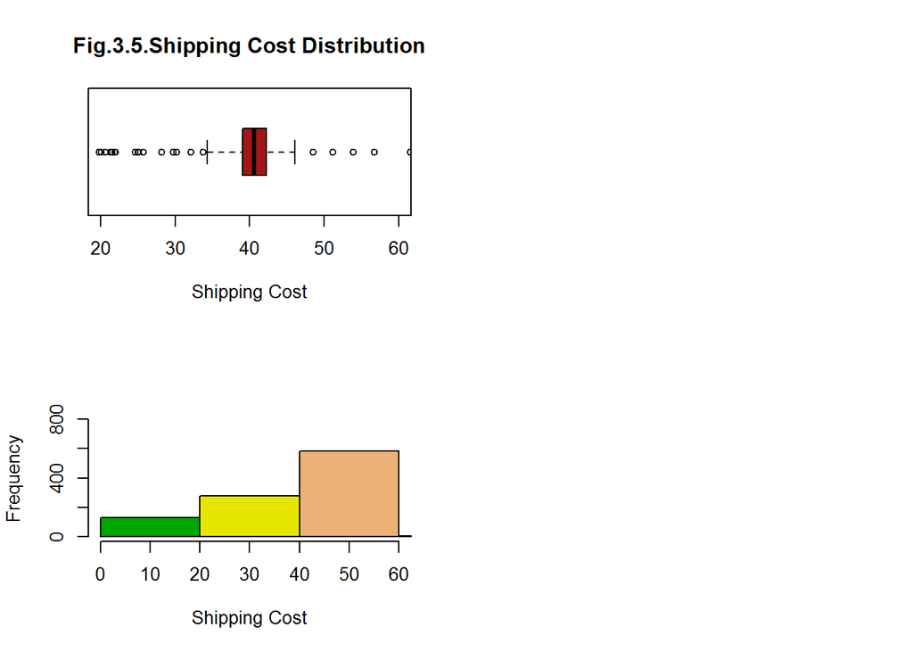

```r
par(mfcol=c(2,2))

boxplot(ship,
        horizontal = TRUE,
        las =1,
        col = c("#A11717", "#2E6DAC"),
        main = "Fig.3.5.Shipping Cost Distribution",
        xlab = "Shipping Cost",
        ylim = c(20,60))

hist(ship,
     col = terrain.colors(4),
     main = NA,
     xlab = "Shipping Cost",
     xlim = c(0,60),
     ylim = c(0,800),
     breaks = 20)
```

Observation:  
Figure 3.5.  
Shipping Cost for approximately 500 of the observations fall in the range of 40-60$  
**Task 4**

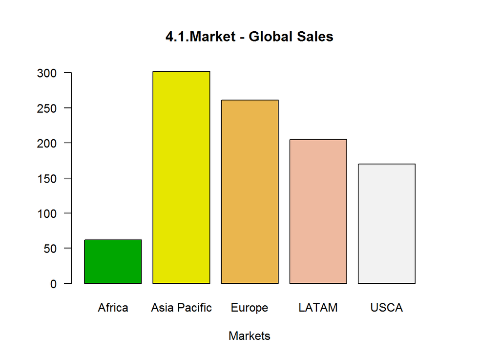

```r
par(mai = c(1,1,1,1))

market <- table(GobalSales$Market)
barplot(market,main = "4.1.Market - Global Sales",xlab = "Markets",col = terrain.colors(5),las = 1)
```

Observation:  
The sales is falling low in Africa.Only 60 we can observe for Africa  
The Asia Pacific market contributes the most to the total sales(300)

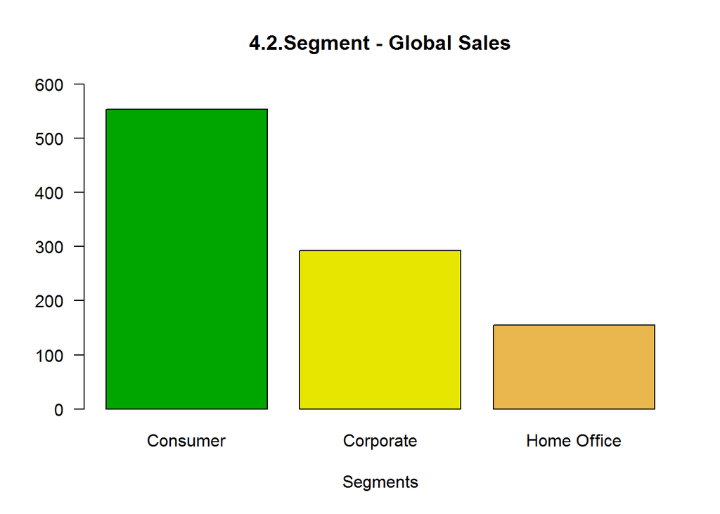

```r
segment <- table(GobalSales$Segment)
barplot(segment,main = "4.2.Segment - Global Sales",xlab = "Segments",col = terrain.colors(5),ylim = c(0,600),las = 1)
```

Observation:  
The home office segment has just 150 share in the total observations  
The consumer segment is contributing the most to our sales(550)

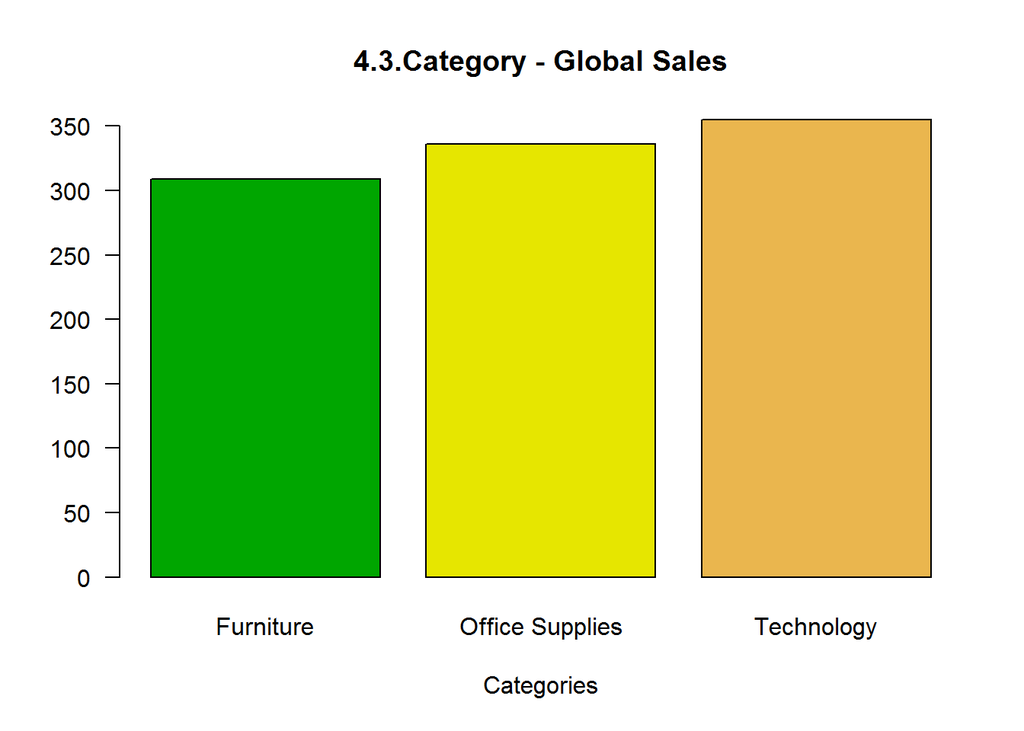

```r
category <- table(GobalSales$Category)
barplot(category,main = "4.3.Category - Global Sales",xlab = "Categories",col = terrain.colors(5),las = 1)
```

**Task 5**  
5.1. The quantity sold was the most for which category?

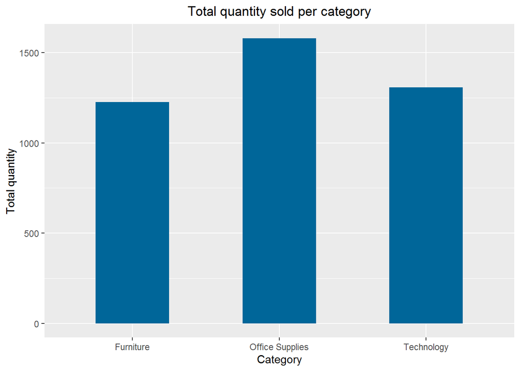

```r
cat_qty <- tapply(GobalSales$Quantity,GobalSales$Category,sum)
Category <- table(GobalSales$Category)
cat_qty1 <- data.frame(Category,cat_qty)

print1 = ggplot(cat_qty1,aes(x=Var1,y=cat_qty)) + geom_bar(stat="identity",width=0.5,fill = "#006699")
print (print1 + labs(x = "Category",y ="Total quantity",title = "Total quantity sold per category") + theme(plot.title = element_text(hjust = 0.5)))
```

Observation:  
Office supplies were sold the most(nearly 1600)  
Furniture was sold the least(about 1200)  
5.2. Among all the markets we considered,the median(the 50th percentile) is least for which market?

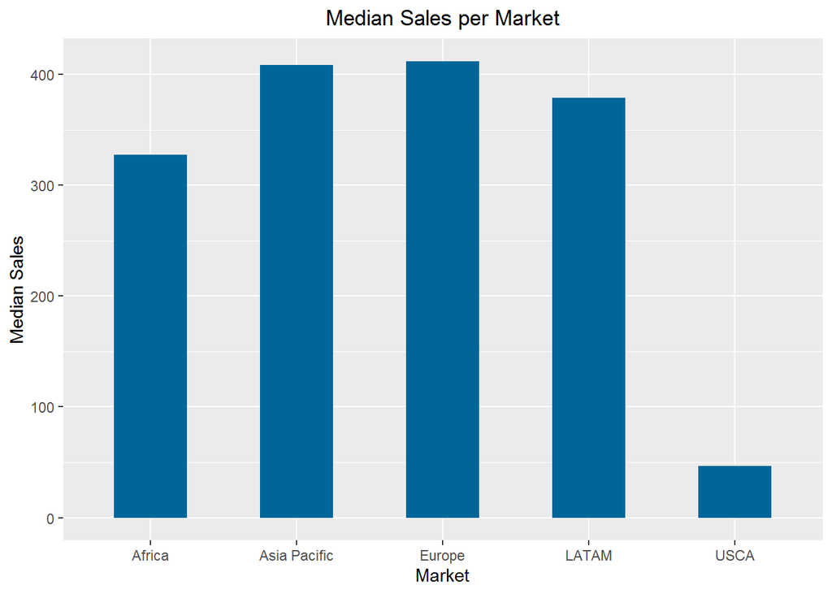

```r
ggplot(GobalSales,aes(x=GobalSales$Market, y=GobalSales$Sales)) + stat_summary(fun=median, geom="bar",width=0.5,fill = "#006699") + labs(x = "Market",y ="Median Sales",title = "Median Sales per Market") + theme(plot.title = element_text(hjust = 0.5))
```

Observation:  
USCA market shows the least median(50) for sales  
Europe and Asia Pacific has sales in the range of 400-450  
5.3. Which segment among consumer,corporate and home-office has the least average profit?

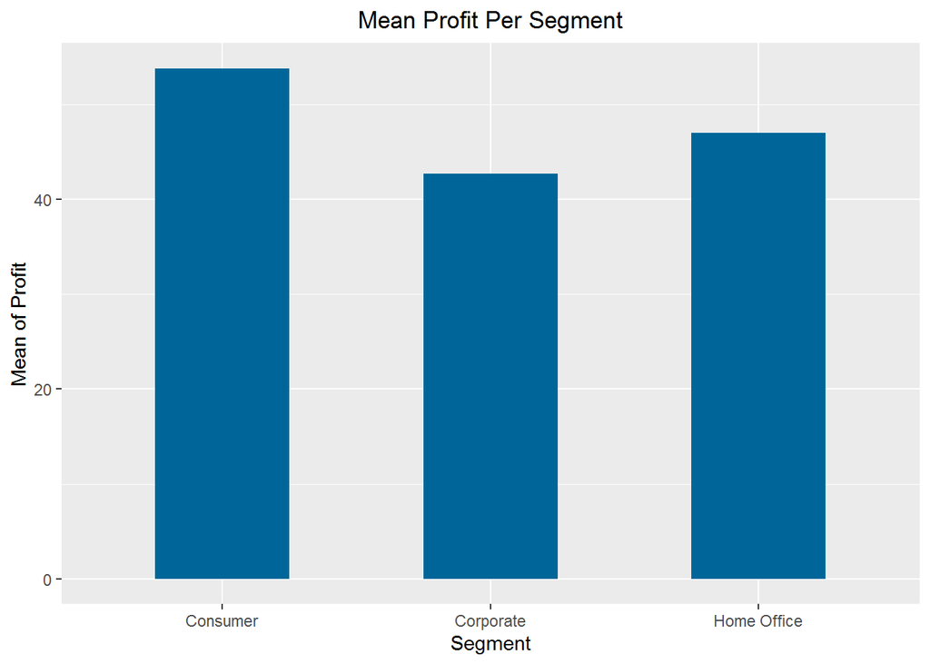

```r
ggplot(GobalSales,aes(x=GobalSales$Segment, y=GobalSales$Profit)) + stat_summary(fun=mean, geom="bar",width=0.5,fill = "#006699") + labs(x = "Segment",y ="Mean of Profit",title = "Mean Profit Per Segment") + theme(plot.title = element_text(hjust = 0.5))
```

Observation:  
From the above bar-plot the following conclusions can be made:  
1) The mean profit is highest for consumer segment  
2) The corporate segment and home-office has similar mean-profits  
**Task 6**  
What is the segment wise preference for shipping mode?

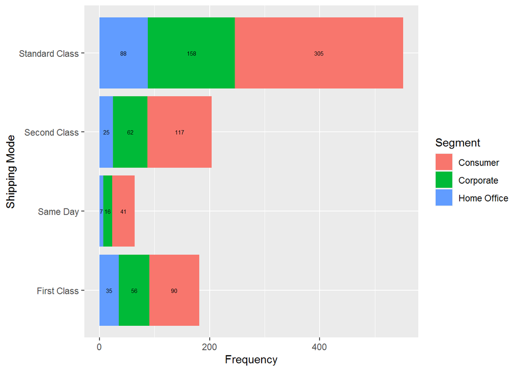

```r
table1 <- table(GobalSales$ShipMode,GobalSales$Segment)

datafr <- as.data.frame(table1)

ggplot(datafr, aes(x=Freq, y=Var1, fill=Var2)) + geom_col()+ xlab("Frequency") + ylab("Shipping Mode") +labs(fill = "Segment")+ geom_text(aes(label = Freq), position = position_stack(vjust= 0.5),

            colour = "Black", size = 2)
```

To answer the above question I plotted the Shipping mode and segment. This will help us to understand the shipping mode preference of the customers belonging to the different segment.

From the below graph it can be inferred that -

1. Standard class looks like the default choice for most of the orders.

3. Same day is the least popular assuming that it has the highest shipping cost.

5. At 62 second class mode and 56 first class shipping mode, corporate segment is second highest in these categories.

6. From above points it can be inferred that Standard is the most preferred shipping choice for all the 3 segments.

**CONCLUSIONS**

The least is observed in Africa market.While office supplies are sold the most in quantity,the profit is more from technology and the sales is also the most in technology.The discount rate is mostly within 20%.  
Recommendations:

The company needs to focus on its sales in the market of Africa. The technology items needs to be marketed.The products under furniture needs to be given preference as the sales are not in par with other categories

Pricing and discounts needs to be reconsidered.  
**BIBLIOGRAPHY**

[1]Bluman,A. G. (2017). Elementary statistics: A step by step approach. New York, NY: McGraw-Hill Education.  
[2]Prof. Dee Chiluiza,PAR function.Rmd  
[3]Dee, Chiluiza(2021). M6 Final Project Information. Retrieved from Canvas.

**APPENDIX**  
An additional R Markdown file containing the R codes has been attached to this report. The name of this file is M6_Final_Project_Ravi.Rmd